# Tugas praktikum 2

Fatih Hizir

2025-08-26

Library Yang Digunakan

```r
library(forecast)
```

```r
library(graphics)
library(TSA)
library(TTR)
library(readxl)
library(Metrics)
```

Impor Data

```r
data_tsla <- read_excel("~/Downloads/TSLA_weekly.xlsx", sheet = "Weekly Data")
data_tsla <- data_tsla[, c("Date", "Close")]

head(data_tsla)
```

```
## # A tibble: 6 × 2
##   Date                Close
##   <dttm>              <dbl>
## 1 2018-01-29 00:00:00  22.9
## 2 2018-02-05 00:00:00  20.7
## 3 2018-02-12 00:00:00  22.4
## 4 2018-02-19 00:00:00  23.5
## 5 2018-02-26 00:00:00  22.3
## 6 2018-03-05 00:00:00  21.8
```

Eksplor Data

```r
str(data_tsla)
```

```
## tibble [198 × 2] (S3: tbl_df/tbl/data.frame)
##  $ Date : POSIXct[1:198], format: "2018-01-29" "2018-02-05" ...
##  $ Close: num [1:198] 22.9 20.7 22.4 23.5 22.3 ...
```

```r
dim(data_tsla)
```

```
## [1] 198   2
```

```r
data_tsla.ts<-ts(data_tsla$Close)
summary(data_tsla.ts)
```

```
##    Min. 1st Qu.  Median    Mean 3rd Qu.    Max.
##   12.34   19.84   27.77   92.01  194.85  407.36
```

Plot data deret waktu

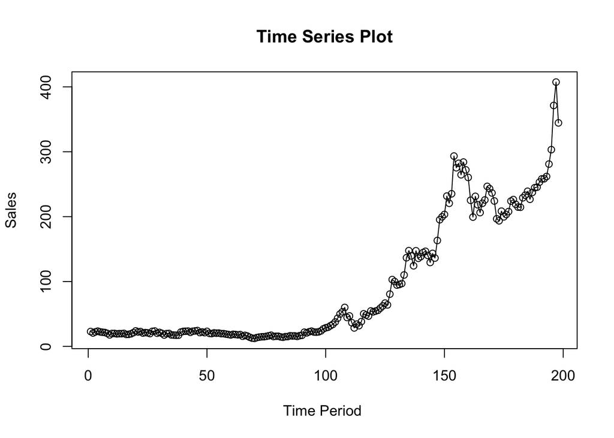

```r
ts.plot(data_tsla.ts, xlab="Time Period ", ylab="Sales",
        main = "Time Series Plot")
points(data_tsla.ts)
```

```r
dev.copy(png, "plot_data2.png")
```

```r
dev.off()
```

Pembagian Data

```r
n <- nrow(data_tsla)

n_train <- floor(0.8 * n)

training_ma <- data_tsla[1:n_train, ]
testing_ma  <- data_tsla[(n_train+1):n, ]

train_ma.ts <- ts(training_ma$Close)
test_ma.ts  <- ts(testing_ma$Close)
```

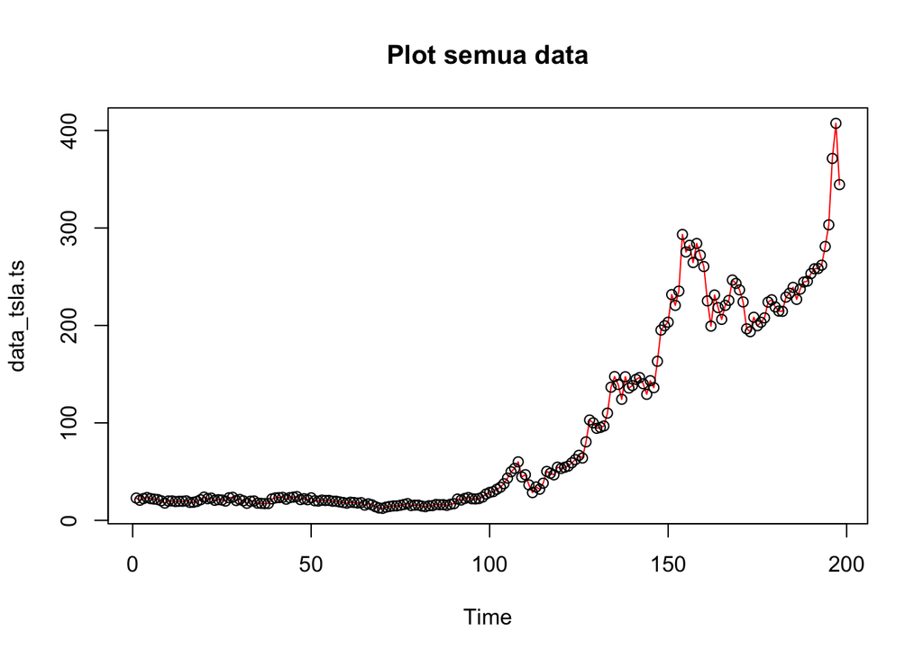

```r
plot(data_tsla.ts, col="red",main="Plot semua data")
points(data_tsla.ts)
```

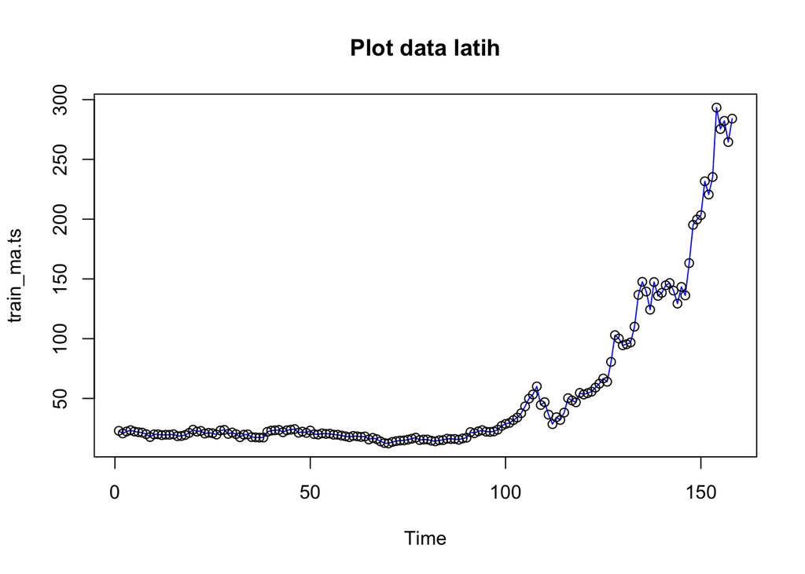

```r
plot(train_ma.ts, col="blue",main="Plot data latih")
points(train_ma.ts)
```

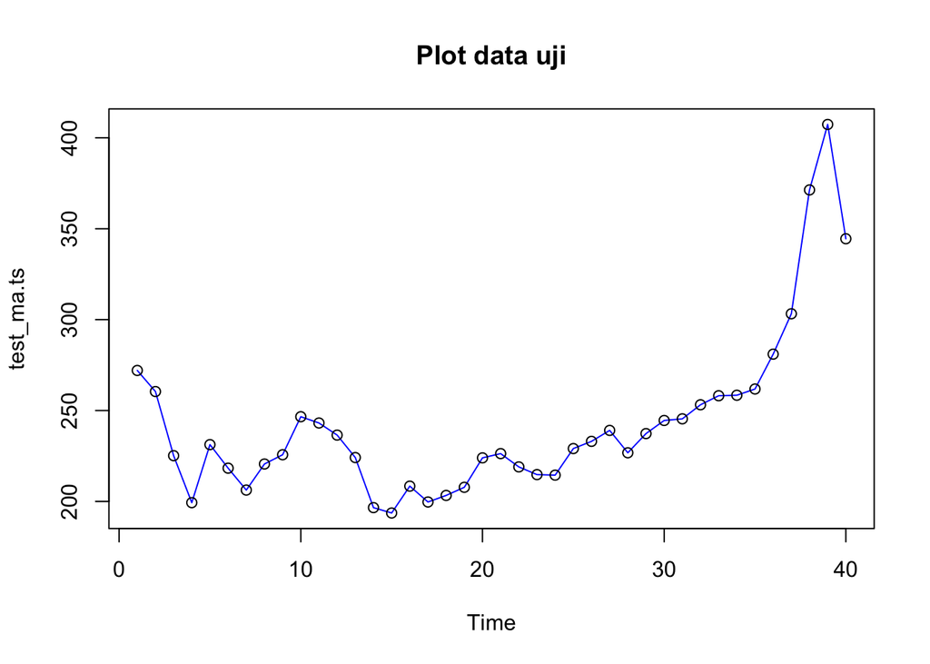

```r
plot(test_ma.ts, col="blue",main="Plot data uji")
points(test_ma.ts)
```

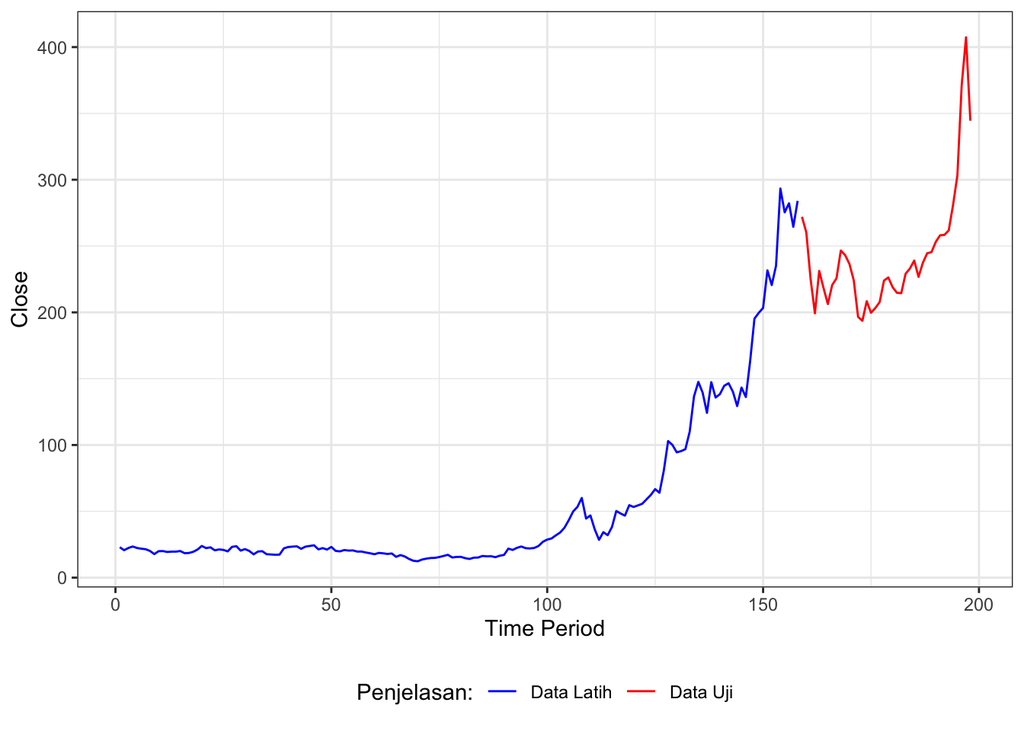

```r
train_df <- data.frame(
  Period = 1:length(train_ma.ts),
  Sales = as.numeric(train_ma.ts),
  Tipe = "Data Latih"
)

test_df <- data.frame(
  Period = (length(train_ma.ts)+1):(length(train_ma.ts)+length(test_ma.ts)),
  Sales = as.numeric(test_ma.ts),
  Tipe = "Data Uji"
)

plot_df <- rbind(train_df, test_df)

library(ggplot2)
ggplot(plot_df, aes(x = Period, y = Sales, col = Tipe)) +
  geom_line() +
  labs(x = "Time Period", y = "Close", color = "Penjelasan:") +
  scale_colour_manual(values = c("Data Latih" = "blue", "Data Uji" = "red")) +
  theme_bw() +
  theme(legend.position = "bottom",
        plot.caption = element_text(hjust=0.5, size=12))
```

### Forecast

```r
## SMA (Simple Moving Average)
sma <- SMA(train_ma.ts, n = 5)   # isi n sesuai kebutuhan
sma_forecast <- rep(tail(na.omit(sma), 1), length(test_ma.ts))

acc_sma <- data.frame(
  Model = "SMA",
  SSE = sum((test_ma.ts - sma_forecast)^2),
  MSE = mean((test_ma.ts - sma_forecast)^2),
  MAE = mae(test_ma.ts, sma_forecast),
  RMSE = rmse(test_ma.ts, sma_forecast),
  MAPE = mape(test_ma.ts, sma_forecast)
)

## DMA (Double Moving Average)
dma <- SMA(na.omit(sma), n = 5)
dma_forecast <- rep(tail(na.omit(dma), 1), length(test_ma.ts))

acc_dma <- data.frame(
  Model = "DMA",
  SSE = sum((test_ma.ts - dma_forecast)^2),
  MSE = mean((test_ma.ts - dma_forecast)^2),
  MAE = mae(test_ma.ts, dma_forecast),
  RMSE = rmse(test_ma.ts, dma_forecast),
  MAPE = mape(test_ma.ts, dma_forecast)
)

## SES (Single Exponential Smoothing)
ses_model <- ses(train_ma.ts, h = length(test_ma.ts))
ses_forecast <- as.numeric(ses_model$mean)

acc_ses <- data.frame(
  Model = "SES",
  SSE = sum((test_ma.ts - ses_forecast)^2),
  MSE = mean((test_ma.ts - ses_forecast)^2),
  MAE = mae(test_ma.ts, ses_forecast),
  RMSE = rmse(test_ma.ts, ses_forecast),
  MAPE = mape(test_ma.ts, ses_forecast)
)

## DES (Double Exponential Smoothing / Holt’s Linear)
des_model <- holt(train_ma.ts, h = length(test_ma.ts))
des_forecast <- as.numeric(des_model$mean)

acc_des <- data.frame(
  Model = "DES",
  SSE = sum((test_ma.ts - des_forecast)^2),
  MSE = mean((test_ma.ts - des_forecast)^2),
  MAE = mae(test_ma.ts, des_forecast),
  RMSE = rmse(test_ma.ts, des_forecast),
  MAPE = mape(test_ma.ts, des_forecast)
)

## Holt-Winters
hw_model <- HoltWinters(train_ma.ts, beta = TRUE, gamma = FALSE)
hw_forecast <- forecast(hw_model, h = length(test_ma.ts))
hw_forecast_values <- as.numeric(hw_forecast$mean)

acc_hw <- data.frame(
  Model = "Holt-Winters",
  SSE = sum((test_ma.ts - hw_forecast_values)^2),
  MSE = mean((test_ma.ts - hw_forecast_values)^2),
  MAE = mae(test_ma.ts, hw_forecast_values),
  RMSE = rmse(test_ma.ts, hw_forecast_values),
  MAPE = mape(test_ma.ts, hw_forecast_values)
)

# -----------------------------
# Gabungkan semua hasil
# -----------------------------
accuracy_table <- rbind(acc_sma, acc_dma, acc_ses, acc_des, acc_hw)

# Tentukan model terbaik berdasarkan RMSE (atau metrik lain)
best_model <- accuracy_table[which.min(accuracy_table$RMSE), ]

print(accuracy_table)
```

```
##          Model        SSE       MSE       MAE      RMSE      MAPE
## 1          SMA  135522.68  3388.067  52.51891  58.20710 0.2250902
## 2          DMA   92105.11  2302.628  38.24052  47.98570 0.1580788
## 3          SES  147679.70  3691.992  55.57530  60.76177 0.2391354
## 4          DES 1357261.59 33931.540 173.66550 184.20516 0.7342174
## 5 Holt-Winters  112608.34  2815.208  42.02497  53.05854 0.1724693
```

```r
print(best_model)
```

```
##   Model      SSE      MSE      MAE    RMSE      MAPE
## 2   DMA 92105.11 2302.628 38.24052 47.9857 0.1580788
```

Visualisasi Perbandingan

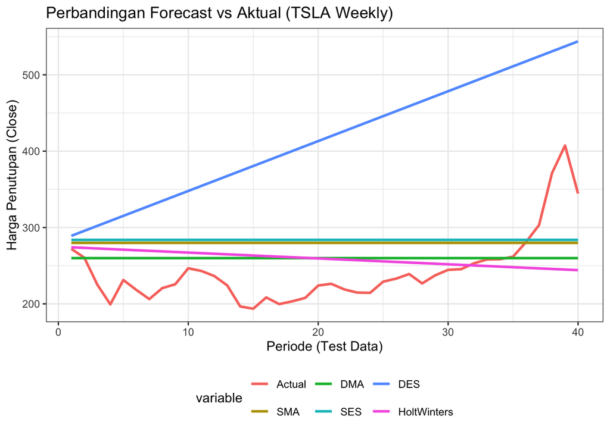

```r
plot_df <- data.frame(
  Period = 1:length(test_ma.ts),
  Actual = as.numeric(test_ma.ts),
  SMA = sma_forecast,
  DMA = dma_forecast,
  SES = ses_forecast,
  DES = des_forecast,
  HoltWinters = hw_forecast_values
)

library(reshape2)
plot_melt <- melt(plot_df, id.vars = "Period")

library(ggplot2)
ggplot(plot_melt, aes(x = Period, y = value, color = variable)) +
  geom_line(size = 1) +
  labs(title = "Perbandingan Forecast vs Aktual (TSLA Weekly)",
       x = "Periode (Test Data)", y = "Harga Penutupan (Close)") +
  theme_bw() +
  theme(legend.position = "bottom")
```

Kesimpulan:  
Berdasarkan hasil analisis peramalan terhadap data harga penutupan mingguan Tesla (TSLA), telah dilakukan perbandingan beberapa metode yaitu Single Moving Average (SMA), Double Moving Average (DMA), Single Exponential Smoothing (SES), Double Exponential Smoothing (DES), dan Holt-Winters. Evaluasi model dilakukan menggunakan metrik akurasi seperti SSE, MSE, MAE, RMSE, dan MAPE. Hasil perhitungan menunjukkan bahwa metode DMA memiliki nilai RMSE dan MAPE paling rendah dibandingkan metode lain, yaitu RMSE sebesar 47,99 dan MAPE sebesar 15,81%. Hal ini mengindikasikan bahwa metode DMA menghasilkan kesalahan prediksi paling kecil serta lebih stabil dalam menggambarkan pola pergerakan harga saham TSLA.